# Linear Regression

Linear regression is a statistical method used to model the relationship between a dependent variable and one or more independent variables. It assumes a linear relationship, meaning that the change in the dependent variable is directly proportional to the changes in the independent variables.

The goal of linear regression is to estimate parameters that best fit the data, minimizing the difference between the predicted values of Y and the actual values. This estimation is typically done using the least squares method, where the sum of squared differences between the predicted and actual values is minimized.

# DataSet

The Data set I will be analyzing here is one which discusses about the personal medical costs in different parts of the US.

This data set includes following features :

1) AGE 2) SEX 3) BMI 4) CHILDREN 5) SMOKER 6) REGION 7) CHARGES

The data set can be found here:

1) Github : https://github.com/stedy/Machine-Learning-with-R-datasets/blob/master/insurance.csv

I have also hosted a website for the predicted model which can be found here: https://yogeshmodel.pythonanywhere.com

# GOAL

1) To find some valuebale insights from the data 2) To make a LR model to predict medical costs billed by health insurance

```python
import pandas as pd
import matplotlib.pyplot as plt
import seaborn as sns
import warnings
warnings.filterwarnings("ignore")
```

The warnings library in Python provides a way to handle warning messages issued by the Python interpreter or other libraries. It allows you to control the behavior of warnings, such as whether to ignore them, display them as errors, or filter specific types of warnings.

```python
medical_data = pd.read_csv("insurance.csv")
medical_data
```

|  | age | sex | bmi | children | smoker | region | charges |
| --- | --- | --- | --- | --- | --- | --- | --- |
| 0 | 19 | female | 27.900 | 0 | yes | southwest | 16884.92400 |
| 1 | 18 | male | 33.770 | 1 | no | southeast | 1725.55230 |
| 2 | 28 | male | 33.000 | 3 | no | southeast | 4449.46200 |
| 3 | 33 | male | 22.705 | 0 | no | northwest | 21984.47061 |
| 4 | 32 | male | 28.880 | 0 | no | northwest | 3866.85520 |
| ... | ... | ... | ... | ... | ... | ... | ... |
| 1333 | 50 | male | 30.970 | 3 | no | northwest | 10600.54830 |
| 1334 | 18 | female | 31.920 | 0 | no | northeast | 2205.98080 |
| 1335 | 18 | female | 36.850 | 0 | no | southeast | 1629.83350 |
| 1336 | 21 | female | 25.800 | 0 | no | southwest | 2007.94500 |
| 1337 | 61 | female | 29.070 | 0 | yes | northwest | 29141.36030 |

1338 rows × 7 columns

```python
medical_data.info()
```

```
<class 'pandas.core.frame.DataFrame'>
RangeIndex: 1338 entries, 0 to 1337
Data columns (total 7 columns):
 #   Column    Non-Null Count  Dtype
---  ------    --------------  -----
 0   age       1338 non-null   int64
 1   sex       1338 non-null   object
 2   bmi       1338 non-null   float64
 3   children  1338 non-null   int64
 4   smoker    1338 non-null   object
 5   region    1338 non-null   object
 6   charges   1338 non-null   float64
dtypes: float64(2), int64(2), object(3)
memory usage: 73.3+ KB
```

1) we have 1338 rows with 7 unique columns with different datatypes

First we check for null values and duplicate values

```python
# checking for nullvalues

null_values = medical_data.isnull().sum()
print(null_values)
```

```
age         0
sex         0
bmi         0
children    0
smoker      0
region      0
charges     0
dtype: int64
```

We can see there are no null values

```python
# checking for duplicate values

duplicates = medical_data.duplicated(keep=False)
duplicate_rows = medical_data[duplicates]
print(duplicate_rows)
```

```
     age   sex    bmi  children smoker     region    charges
195   19  male  30.59         0     no  northwest  1639.5631
581   19  male  30.59         0     no  northwest  1639.5631
```

```python
# we need to drop the duplicate row

medical_data = medical_data.drop_duplicates()
medical_data.shape
```

```
(1337, 7)
```

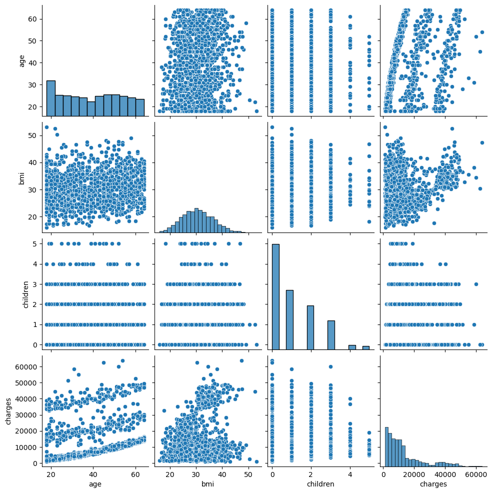

```python
# plotting a pair plot for a elementary analysis

sns.pairplot(medical_data)
```

```python
# let us make a index column for easier analysis using indexing

medical_data.reset_index(inplace = True)
```

```python
medical_data.head()
```

|  | index | age | sex | bmi | children | smoker | region | charges |
| --- | --- | --- | --- | --- | --- | --- | --- | --- |
| 0 | 0 | 19 | female | 27.900 | 0 | yes | southwest | 16884.92400 |
| 1 | 1 | 18 | male | 33.770 | 1 | no | southeast | 1725.55230 |
| 2 | 2 | 28 | male | 33.000 | 3 | no | southeast | 4449.46200 |
| 3 | 3 | 33 | male | 22.705 | 0 | no | northwest | 21984.47061 |
| 4 | 4 | 32 | male | 28.880 | 0 | no | northwest | 3866.85520 |

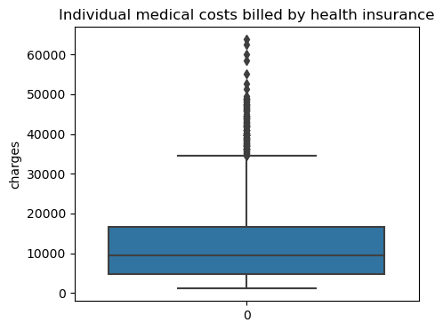

```python
# plotting charges to see behaviour of charges

plt.figure(figsize=(5,4))
sns.boxplot(medical_data['charges'])
plt.title("Individual medical costs billed by health insurance")
plt.ylabel("charges")
plt.show()
```

We have used a box plot here which helps us to visualize the outliers , Highest value, lowest value and the median of the data

This shows us that we have some outliers in our data set

```python
medical_data.describe(include = "all")
```

|  | index | age | sex | bmi | children | smoker | region | charges |
| --- | --- | --- | --- | --- | --- | --- | --- | --- |
| count | 1337.000000 | 1337.000000 | 1337 | 1337.000000 | 1337.000000 | 1337 | 1337 | 1337.000000 |
| unique | NaN | NaN | 2 | NaN | NaN | 2 | 4 | NaN |
| top | NaN | NaN | male | NaN | NaN | no | southeast | NaN |
| freq | NaN | NaN | 675 | NaN | NaN | 1063 | 364 | NaN |
| mean | 668.565445 | 39.222139 | NaN | 30.663452 | 1.095737 | NaN | NaN | 13279.121487 |
| std | 386.528803 | 14.044333 | NaN | 6.100468 | 1.205571 | NaN | NaN | 12110.359656 |
| min | 0.000000 | 18.000000 | NaN | 15.960000 | 0.000000 | NaN | NaN | 1121.873900 |
| 25% | 334.000000 | 27.000000 | NaN | 26.290000 | 0.000000 | NaN | NaN | 4746.344000 |
| 50% | 669.000000 | 39.000000 | NaN | 30.400000 | 1.000000 | NaN | NaN | 9386.161300 |
| 75% | 1003.000000 | 51.000000 | NaN | 34.700000 | 2.000000 | NaN | NaN | 16657.717450 |
| max | 1337.000000 | 64.000000 | NaN | 53.130000 | 5.000000 | NaN | NaN | 63770.428010 |

We can see from the graph and the data that the charges have high standard deviation and hence there must be outliers in the data , we need to take care of them but since our data set is small these outliers must not make a problem , Bills above 38000 can be considered outliers , lets see how many outliers we have

```python
medical_data[medical_data['charges']>38000].count().reset_index()
```

|  | index | 0 |
| --- | --- | --- |
| 0 | index | 103 |
| 1 | age | 103 |
| 2 | sex | 103 |
| 3 | bmi | 103 |
| 4 | children | 103 |
| 5 | smoker | 103 |
| 6 | region | 103 |
| 7 | charges | 103 |

There are only 103 outliers hence we can use them for futheer anaylsis there is no need to drop them

### Relation of gender and age on medical insurance bills

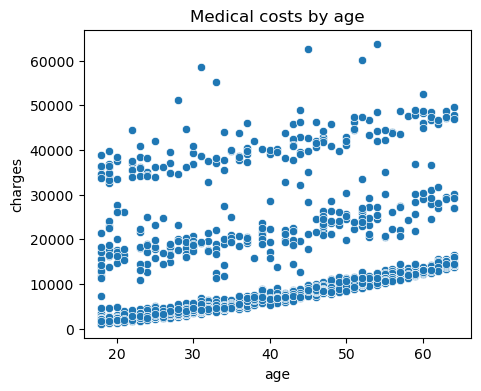

```python
plt.figure(figsize=(5,4))
sns.scatterplot(data=medical_data, x='age', y='charges')
plt.title("Medical costs by age")
plt.show()
```

We can see how with age the medical expenses increase hence charges are related to age of the person

Let us now try to analyze the same using gender and age

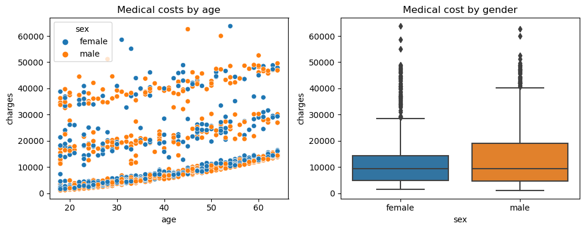

```python
fig, axes = plt.subplots(1, 2, figsize = (10,4))

sns.scatterplot(data=medical_data, x='age', y='charges', hue="sex", ax=axes[0])
axes[0].set_title("Medical costs by age")

sns.boxplot(data=medical_data, x='sex', y='charges', ax=axes[1])
axes[1].set_title("Medical cost by gender")

plt.tight_layout()
plt.show()
```

```python
medical_data.groupby(['sex'])['charges'].mean()
```

```
sex
female    12569.578844
male      13974.998864
Name: charges, dtype: float64
```

We can see men tend to pay more medical bills , this men tend to have more health concerns than females

### Relation of BMI on medical insurance bills

we can refer to govt Data for BMI ranges and check if pople fall in them

1) If your BMI is less than 18.5, it falls within the underweight range. 2) If your BMI is 18.5 to 24.9, it falls within the Healthy Weight range. 3) If your BMI is 25.0 to 29.9, it falls within the overweight range. 4) If your BMI is 30.0 or higher, it falls within the obese range.

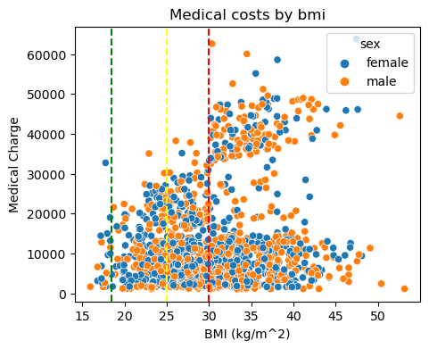

```python
plt.figure(figsize=(5,4))
sns.scatterplot(data=medical_data, x='bmi', y='charges', hue='sex')
plt.axvline(x=18.5, color="green", linestyle = '--')  # under 18.5 - underweight, between 18.5~24.9 - Normal
plt.axvline(x=25, color = "yellow", linestyle = '--')  # between 25~29.9 - Overweight
plt.axvline(x=30, color = "red", linestyle = '--')     # Over 30 - Obese
plt.title("Medical costs by bmi")
plt.xlabel("BMI (kg/m^2)")
plt.ylabel("Medical Charge")
plt.show()
```

```python
bins_bmi = [medical_data['bmi'].min(), 18.5, 25, 30, medical_data['bmi'].max()]
charges_30k = medical_data[medical_data['charges']>30000]
charges_30k['bmi'].value_counts(bins=bins_bmi, sort=False).rename_axis('BMI Group').reset_index(name='Numbers of Individuals')
```

|  | BMI Group | Numbers of Individuals |
| --- | --- | --- |
| 0 | (15.959000000000001, 18.5] | 1 |
| 1 | (18.5, 25.0] | 2 |
| 2 | (25.0, 30.0] | 10 |
| 3 | (30.0, 53.13] | 149 |

This shows individuals with higher BMI tend to pay more hospital bills , hence are more prone to diseases But why only some obese people tend to pay higher bills?

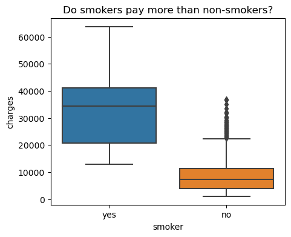

```python
plt.figure(figsize=(5,4))
sns.boxplot(data=medical_data, x='smoker',y='charges')
plt.title("Do smokers pay more than non-smokers?")
plt.show()
```

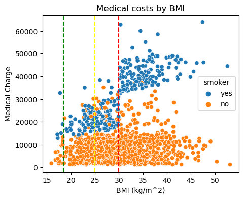

```python
plt.figure(figsize=(5,4))
sns.scatterplot(data=medical_data, x='bmi', y='charges', hue='smoker')
plt.axvline(x=18.5, color='green', linestyle = '--')  # under 18.5 - underweight, between 18.5~24.9 - Normal
plt.axvline(x=25, color = 'yellow', linestyle = '--')  # between 25~29.9 - Overweight
plt.axvline(x=30, color = 'red', linestyle = '--')     # Over 30 - Obese
plt.title("Medical costs by BMI")
plt.xlabel("BMI (kg/m^2)")
plt.ylabel("Medical Charge")
plt.show()
```

```python
medical_data.groupby(['smoker'])['charges'].mean()
```

```
smoker
no      8440.660307
yes    32050.231832
Name: charges, dtype: float64
```

1) The above graph and data shows how smokers have higher bill data. 2) Also we get to know why all obese people dont pay high bills because smoking factor comes in

### Applying the linear regression model

First we need to convert categorical values to intger values

```python
medical_data.info()
```

```
<class 'pandas.core.frame.DataFrame'>
RangeIndex: 1337 entries, 0 to 1336
Data columns (total 8 columns):
 #   Column    Non-Null Count  Dtype
---  ------    --------------  -----
 0   index     1337 non-null   int64
 1   age       1337 non-null   int64
 2   sex       1337 non-null   object
 3   bmi       1337 non-null   float64
 4   children  1337 non-null   int64
 5   smoker    1337 non-null   object
 6   region    1337 non-null   object
 7   charges   1337 non-null   float64
dtypes: float64(2), int64(3), object(3)
memory usage: 83.7+ KB
```

We can see sex , smoker and region are categorical value , we need to convert them to binary

```python
medical_data_model = pd.get_dummies(medical_data, columns = ['sex', 'smoker', 'region'], dtype = "int64")
```

```python
medical_data_model.head()
```

|  | index | age | bmi | children | charges | sex_female | sex_male | smoker_no | smoker_yes | region_northeast | region_northwest | region_southeast | region_southwest |
| --- | --- | --- | --- | --- | --- | --- | --- | --- | --- | --- | --- | --- | --- |
| 0 | 0 | 19 | 27.900 | 0 | 16884.92400 | 1 | 0 | 0 | 1 | 0 | 0 | 0 | 1 |
| 1 | 1 | 18 | 33.770 | 1 | 1725.55230 | 0 | 1 | 1 | 0 | 0 | 0 | 1 | 0 |
| 2 | 2 | 28 | 33.000 | 3 | 4449.46200 | 0 | 1 | 1 | 0 | 0 | 0 | 1 | 0 |
| 3 | 3 | 33 | 22.705 | 0 | 21984.47061 | 0 | 1 | 1 | 0 | 0 | 1 | 0 | 0 |
| 4 | 4 | 32 | 28.880 | 0 | 3866.85520 | 0 | 1 | 1 | 0 | 0 | 1 | 0 | 0 |

we need to drop redundant columns

```python
medical_data_model = medical_data_model.drop(['index', 'sex_female', 'smoker_no'], axis=1)
medical_data_model.rename(columns = {'sex_male':'sex', 'smoker_yes':'smoker'}, inplace = True)
```

```python
medical_data_model.head()
```

|  | age | bmi | children | charges | sex | smoker | region_northeast | region_northwest | region_southeast | region_southwest |
| --- | --- | --- | --- | --- | --- | --- | --- | --- | --- | --- |
| 0 | 19 | 27.900 | 0 | 16884.92400 | 0 | 1 | 0 | 0 | 0 | 1 |
| 1 | 18 | 33.770 | 1 | 1725.55230 | 1 | 0 | 0 | 0 | 1 | 0 |
| 2 | 28 | 33.000 | 3 | 4449.46200 | 1 | 0 | 0 | 0 | 1 | 0 |
| 3 | 33 | 22.705 | 0 | 21984.47061 | 1 | 0 | 0 | 1 | 0 | 0 |
| 4 | 32 | 28.880 | 0 | 3866.85520 | 1 | 0 | 0 | 1 | 0 | 0 |

Now we can plot a correlational heatmap to get more insights on dependent variables

## Correlation in dataset

Correlation refers to the statistical relationship between two or more variables in a dataset. It measures the degree to which the variables are linearly related. Correlation is commonly used to understand the strength and direction of the relationship between variables.

A correlation value ranges from -1 to 1. A correlation coefficient of -1 indicates a perfect negative correlation, where the variables move in opposite directions. A correlation coefficient of 1 indicates a perfect positive correlation, where the variables move in the same direction. A correlation coefficient close to 0 suggests a weak or no correlation between the variables.

Heatmaps are graphical representations of data using a color-coded matrix. In the context of correlation, heatmaps are commonly used to visualize the correlation matrix, which shows the correlation coefficients between pairs of variables in a dataset. The heatmap uses a color gradient to represent the strength of the correlation: warmer colors (e.g., red) indicate higher positive correlation, cooler colors (e.g., blue) indicate higher negative correlation, and neutral colors (e.g., white) represent no or weak correlation.

#### Handling correlation

Handling correlations in data preprocessing involves identifying and addressing potential issues that may arise due to correlated variables. Here are a few approaches to handle correlations:

1) Feature Selection: If you have highly correlated variables, you can select a subset of features based on their importance or relevance to the problem. This can help reduce the dimensionality of the dataset and eliminate redundant information.

2) Principal Component Analysis (PCA): PCA is a dimensionality reduction technique that can be used to transform correlated variables into a set of uncorrelated variables called principal components. These components capture the maximum variance in the data, allowing you to represent the data in a lower-dimensional space while preserving the most important information.

3) Feature Engineering: You can create new features from the existing ones by combining or transforming them. For example, you can compute ratios, differences, or interaction terms between correlated variables to create new features that provide unique information. This can help mitigate the issues caused by multicollinearity.

4) Regularization: Regularization techniques, such as Ridge regression or Lasso regression, can be used to handle correlated variables in predictive modeling. These methods introduce penalties on the model coefficients, encouraging them to be small or zero, effectively reducing the impact of correlated variables.

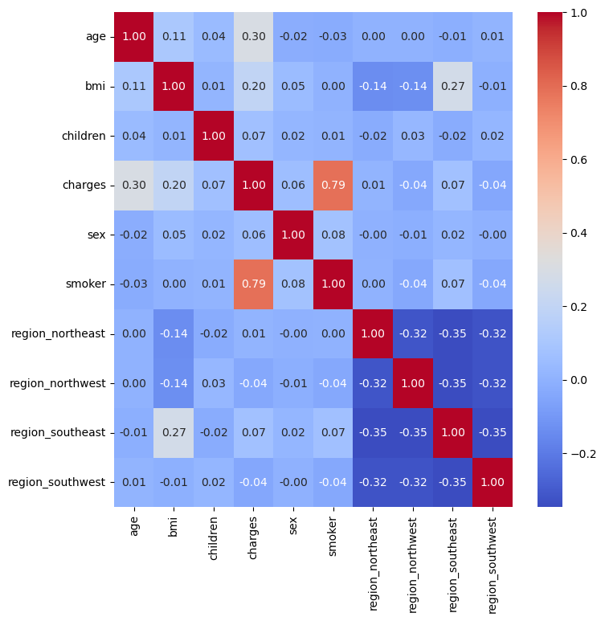

```python
df_corr = medical_data_model.corr()

plt.figure(figsize = (8,8))
sns.heatmap(df_corr, annot=True, fmt=".2f", cmap="coolwarm" )
```

### Fitting Data into Linear Regression Model

```python
from sklearn.model_selection import train_test_split
from sklearn.linear_model import LinearRegression
from sklearn.preprocessing import OneHotEncoder, StandardScaler
from sklearn.compose import ColumnTransformer
from sklearn.metrics import mean_squared_error
from sklearn.preprocessing import StandardScaler
from sklearn.preprocessing import MinMaxScaler
from sklearn.metrics import mean_squared_error, r2_score
import lightgbm as ltb
import xgboost as xgb
from sklearn.ensemble import RandomForestRegressor
from sklearn import tree
from sklearn.metrics import mean_absolute_error, mean_squared_error
```

```python
medical_data.head()
```

|  | index | age | sex | bmi | children | smoker | region | charges |
| --- | --- | --- | --- | --- | --- | --- | --- | --- |
| 0 | 0 | 19 | female | 27.900 | 0 | yes | southwest | 16884.92400 |
| 1 | 1 | 18 | male | 33.770 | 1 | no | southeast | 1725.55230 |
| 2 | 2 | 28 | male | 33.000 | 3 | no | southeast | 4449.46200 |
| 3 | 3 | 33 | male | 22.705 | 0 | no | northwest | 21984.47061 |
| 4 | 4 | 32 | male | 28.880 | 0 | no | northwest | 3866.85520 |

```python
# first we need no drop the charges column to analyize the data

X = medical_data.drop(["charges"] , axis=1)
X.head()
```

|  | index | age | sex | bmi | children | smoker | region |
| --- | --- | --- | --- | --- | --- | --- | --- |
| 0 | 0 | 19 | female | 27.900 | 0 | yes | southwest |
| 1 | 1 | 18 | male | 33.770 | 1 | no | southeast |
| 2 | 2 | 28 | male | 33.000 | 3 | no | southeast |
| 3 | 3 | 33 | male | 22.705 | 0 | no | northwest |
| 4 | 4 | 32 | male | 28.880 | 0 | no | northwest |

```python
y = medical_data['charges']
y.head()
```

```
0    16884.92400
1     1725.55230
2     4449.46200
3    21984.47061
4     3866.85520
Name: charges, dtype: float64
```

```python
# we will know split the data into training set and the test set to check accuracy of our model

X_train, X_test, y_train, y_test = train_test_split(X, y, test_size=0.33, random_state=42)
```

In this example, X represents the feature data, y represents the target variable, and test_size indicates the proportion of the data to be allocated to the test set (33% in this case). The random_state parameter is used to ensure reproducibility, so that the split is consistent across multiple runs.

```python
# we need to take out categorical values into integer values for out model to work
```

The ColumnTransformer class is particularly useful when dealing with datasets that have heterogeneous data types or require different preprocessing steps for different subsets of features.

This is how we apply the class:

1) Define the transformers: Specify the transformers to be applied to specific subsets of columns. For example, you might want to apply one-hot encoding to categorical features and standard scaling to numerical features. 2) Fit and transform the data: The fit_transform method fits the transformers to the training data and applies the transformations to produce the transformed data. The transform method applies the previously fitted transformers to the test data.

```python
numerical_columns = ['age','bmi' , 'children']
categorical_columns = ['sex','smoker', 'region']
```

```python
preprocessor = ColumnTransformer(
    transformers=[
        ('num', "passthrough", numerical_columns),
        ('cat', OneHotEncoder(sparse_output = False, drop = "if_binary"), categorical_columns)
    ])

# here we have defined how to process the data
```

1) The StandardScaler is a preprocessing class in scikit-learn that is used for standardizing numerical features in a dataset. It is a commonly used technique in machine learning to transform numerical data so that it has a mean of 0 and a standard deviation of 1.

2) The OneHotEncoder is a preprocessing class in scikit-learn that is used to transform categorical features into a binary one-hot encoded representation. It is a common technique used in machine learning to convert categorical variables into a numerical format that can be used by machine learning algorithms.

3) fit_transform is used on the training data (X_train) to learn the unique categories and transform the categorical features into one-hot encoded representation. Then, the same encoder object is used to transform the test data (X_test) using the learned categories.

```python
X_train = preprocessor.fit_transform(X_train) # transforming the data according to our preprocssor
```

```python
X_train.shape
```

```
(895, 9)
```

```python
X_train[0]
```

```
array([45.   , 30.495,  1.   ,  0.   ,  1.   ,  0.   ,  1.   ,  0.   ,
        0.   ])
```

```python
models = pd.DataFrame(columns=["Model","MSE","R2 Score"])
```

### Linear regression

```python
linear_model = LinearRegression()
results = linear_model.fit(X_train, y_train)
X_test = preprocessor.transform(X_test)
y_predict = linear_model.predict(X_test)
```

```python
mse = mean_squared_error(y_test, y_predict)
r2 = r2_score(y_test, y_predict)
mae = mean_absolute_error(y_test, y_predict)
rmse = mean_squared_error(y_test, y_predict, squared=False)
print(f"Mean Squared error: {mse}" )
print(f"R squared: {r2}" )
print(f"mean absoulte error: {mae}" )
print(f"mean squared error: {rmse}" )

new_row = {"Model": "Linear Regression","MSE": mse, "R2 Score": r2 , "MAE": mae, "RMSE":rmse}
models = models.append(new_row, ignore_index=True)
```

```
Mean Squared error: 38565934.50286132
R squared: 0.7732755908459318
mean absoulte error: 4190.934869866732
mean squared error: 6210.147703787835
```

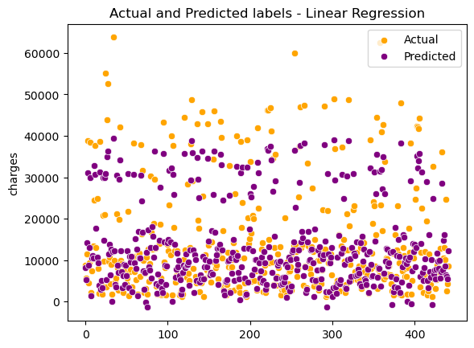

```python
sns.scatterplot(y = y_test, x = range(len(y_test)), color  ='orange', label = "Actual")
sns.scatterplot(y = y_predict, x = range(len(y_predict)), color = 'purple', label = "Predicted")
plt.title("Actual and Predicted labels - Linear Regression")
plt.show()
```

#### XGboost Regression

1) Regularization: XGBoost uses regularization techniques to prevent overfitting and improve generalization.

2) Handling missing values: XGBoost can automatically handle missing values in the dataset, reducing the need for data preprocessing.

3) Feature importance: XGBoost provides insights into the importance of features in the prediction task, helping to identify the most influential variables.

4) Handling imbalanced datasets: XGBoost includes strategies to handle imbalanced datasets, where the number of instances in different classes is disproportionate.

5) Scalability: XGBoost is designed for efficiency and scalability, making it suitable for large datasets and parallel processing.

```python
xgbr = xgb.XGBRegressor(random_state =0)
xgbr.fit(X_train, y_train)
y_xgbr = xgbr.predict(X_test)
```

```python
mse = mean_squared_error(y_test, y_xgbr)
r2 = r2_score(y_test, y_xgbr)
mae = mean_absolute_error(y_test, y_xgbr)
rmse = mean_squared_error(y_test, y_xgbr, squared=False)
print(f"Mean Squared error: {mse}" )
print(f"R squared: {r2}" )
print(f"mean absoulte error: {mae}" )
print(f"mean squared error: {rmse}" )

new_row = {"Model": "XGBoost Regression","MSE": mse, "R2 Score": r2 , "MAE": mae, "RMSE":rmse}
models = models.append(new_row, ignore_index=True)
```

```
Mean Squared error: 27538033.0559948
R squared: 0.8381072738319775
mean absoulte error: 2890.0148363279836
mean squared error: 5247.669297506733
```

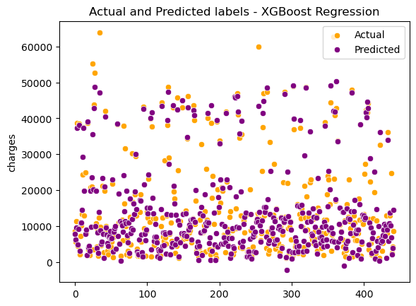

```python
sns.scatterplot(y = y_test, x = range(len(y_test)), color  ='orange', label = "Actual")
sns.scatterplot(y = y_xgbr, x = range(len(y_xgbr)), color = 'purple', label = "Predicted")
plt.title("Actual and Predicted labels - XGBoost Regression")
plt.show()
```

#### LightGBM regression

LightGBM (Light Gradient Boosting Machine) is a gradient boosting framework that uses tree-based learning algorithms. LightGBM regression is a variant of LightGBM specifically designed for regression tasks.

1) Efficiency and speed: LightGBM is designed to be highly efficient and can handle large-scale datasets with millions of instances and thousands of features. It employs techniques such as histogram-based binning and parallel learning to achieve faster training and prediction times.

2) Handling categorical features: LightGBM natively supports categorical features without requiring one-hot encoding. It can directly work with categorical variables and can automatically find the best split points for categorical features during tree construction.

3) Flexibility and customization: LightGBM provides numerous hyperparameters that can be tuned to customize the model's behavior and optimize performance. It offers options to control tree growth, regularization, learning rates, and more.

4) High accuracy: LightGBM has shown competitive performance on various benchmark datasets and is known for its ability to handle complex patterns and capture nonlinear relationships between features and the target variable.

```python
lgbm = ltb.LGBMRegressor()
lgbm.fit(X_train, y_train)
y_lgbm = lgbm.predict(X_test)
```

```python
mse = mean_squared_error(y_test, y_lgbm)
r2 = r2_score(y_test, y_lgbm)
mae = mean_absolute_error(y_test, y_lgbm)
rmse = mean_squared_error(y_test, y_lgbm, squared=False)
print(f"Mean Squared error: {mse}" )
print(f"R squared: {r2}" )
print(f"mean absoulte error: {mae}" )
print(f"mean squared error: {rmse}" )

new_row = {"Model": "LightGBM regression","MSE": mse, "R2 Score": r2 , "MAE": mae, "RMSE":rmse}
models = models.append(new_row, ignore_index=True)
```

```
Mean Squared error: 24206940.918975655
R squared: 0.8576903568387537
mean absoulte error: 2810.7799838499323
mean squared error: 4920.054971133519
```

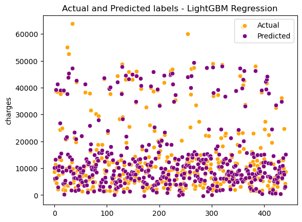

```python
sns.scatterplot(y = y_test, x = range(len(y_test)), color  ='orange', label = "Actual")
sns.scatterplot(y = y_lgbm, x = range(len(y_lgbm)), color = 'purple', label = "Predicted")
plt.title("Actual and Predicted labels - LightGBM Regression")
plt.show()
```

#### Random Forest Regression

Random Forest Regression is a machine learning algorithm that uses an ensemble of decision trees for regression tasks. It is an extension of the Random Forest algorithm, which is widely used for classification tasks.

1) Robustness to noise and outliers: Random Forest Regression can handle noisy and outlier-prone data due to the averaging effect of multiple trees. Outliers have less impact on the final prediction compared to individual decision trees.

2) Nonlinearity and interactions: Random Forest Regression can capture complex nonlinear relationships and interactions between features and the target variable. It can handle both categorical and numerical features without requiring feature scaling or one-hot encoding.

3) Feature importance: Random Forest Regression provides a measure of feature importance, indicating which features are most influential in making predictions. This information can be valuable for feature selection and understanding the underlying patterns in the data.

4) Handling missing values: Random Forest Regression can handle missing values in the dataset by using surrogate splits. It leverages other features to make accurate predictions even when some values are missing.

```python
random_forest = RandomForestRegressor(n_estimators=100, random_state=42)
random_forest.fit(X_train, y_train)
y_rf = random_forest.predict(X_test)
```

```python
mse = mean_squared_error(y_test, y_rf)
r2 = r2_score(y_test, y_rf)
mae = mean_absolute_error(y_test, y_rf)
rmse = mean_squared_error(y_test, y_rf, squared=False)
print(f"Mean Squared error: {mse}" )
print(f"R squared: {r2}" )
print(f"mean absoulte error: {mae}" )
print(f"mean squared error: {rmse}" )

new_row = {"Model": "Random Forest Regression","MSE": mse, "R2 Score": r2 , "MAE": mae, "RMSE":rmse}
models = models.append(new_row, ignore_index=True)
```

```
Mean Squared error: 22092850.821999095
R squared: 0.8701188337916437
mean absoulte error: 2517.2268961056566
mean squared error: 4700.3032691518
```

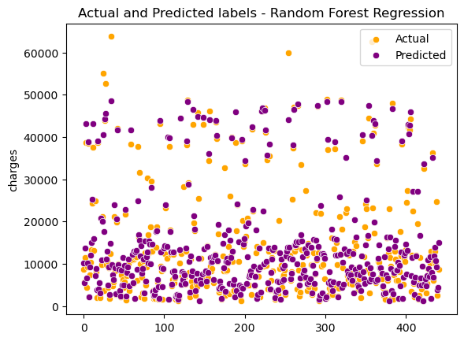

```python
sns.scatterplot(y = y_test, x = range(len(y_test)), color  ='orange', label = "Actual")
sns.scatterplot(y = y_rf, x = range(len(y_rf)), color = 'purple', label = "Predicted")
plt.title("Actual and Predicted labels - Random Forest Regression")
plt.show()
```

```python
models.sort_values(by="R2 Score", ascending=False)
```

|  | Model | MSE | R2 Score | MAE | RMSE |
| --- | --- | --- | --- | --- | --- |
| 3 | Random Forest Regression | 2.209285e+07 | 0.870119 | 2517.226896 | 4700.303269 |
| 2 | LightGBM regression | 2.420694e+07 | 0.857690 | 2810.779984 | 4920.054971 |
| 1 | XGBoost Regression | 2.753803e+07 | 0.838107 | 2890.014836 | 5247.669298 |
| 0 | Linear Regression | 3.856593e+07 | 0.773276 | 4190.934870 | 6210.147704 |

### Pickling the Model

```python
import pickle
```

```python
# we will pickle our trained model with best fit that is Random Forest Regression

with open('RFmodel.pkl', 'wb') as file:
    pickle.dump(random_forest, file)
```

### Predicting the new Dataset using the pickled Dataset

we will generate a synthetic data set for our model:

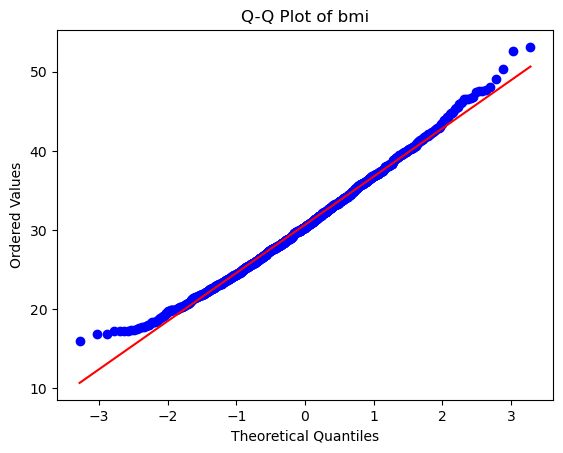

```python
import scipy.stats as stats

# Create a Q-Q plot of the column against a normal distribution
stats.probplot(medical_data['bmi'], dist="norm", plot=plt)
plt.xlabel('Theoretical Quantiles')
plt.ylabel('Ordered Values')
plt.title('Q-Q Plot of bmi')
plt.show()
```

we plot our bmi in a Q-Q plot showing distribution deviation from the normal distribution hence we can safely assume normal distribution of BMI from 15-55

```python
# now we can start making our new synthetic dataset
import numpy as np
num_samples = 5000 #number of samples

# synthetic data for each dataset

age = np.random.randint(18, 65, size=num_samples)  # Random ages between 18 and 65
sex = np.random.choice(['male', 'female'], size=num_samples)
smoker = np.random.choice(['yes', 'no'], size=num_samples)
bmi = np.random.normal(30, 6, size=num_samples)  # Normal distribution with mean 30 and standard deviation 5
children = np.random.randint(0, 5, size=num_samples)  # Random number of children between 0 and 3
region = np.random.choice(['northeast', 'northwest', 'southeast', 'southwest'], size=num_samples)

# Create a DataFrame to store the synthetic data
synthetic_medical_data = pd.DataFrame({
    'age': age,
    'sex': sex,
    'smoker': smoker,
    'BMI': bmi,
    'children': children,
    'region': region
})

# Display the first few rows of the new dataset
print(synthetic_medical_data.head())

# Save the synthetic dataset to a CSV file
synthetic_medical_data.to_csv('synthetic_medical_data.csv', index=False)
```

```
   age     sex smoker        BMI  children     region
0   23    male     no  30.593565         3  northeast
1   59    male     no  38.012515         3  southwest
2   63    male     no  18.999836         2  southeast
3   44  female    yes  25.125429         3  southeast
4   27    male    yes  19.783942         4  southeast
```

Now we can repeat the above procedure to predict the model

```python
synthetic_medical_data = pd.read_csv("synthetic_medical_data.csv")
```

```python
synthetic_medical_data.head()
```

|  | age | sex | smoker | BMI | children | region |
| --- | --- | --- | --- | --- | --- | --- |
| 0 | 23 | male | no | 30.593565 | 3 | northeast |
| 1 | 59 | male | no | 38.012515 | 3 | southwest |
| 2 | 63 | male | no | 18.999836 | 2 | southeast |
| 3 | 44 | female | yes | 25.125429 | 3 | southeast |
| 4 | 27 | male | yes | 19.783942 | 4 | southeast |

```python
synthetic_medical_data.describe(include = "all")
```

|  | age | sex | smoker | BMI | children | region |
| --- | --- | --- | --- | --- | --- | --- |
| count | 5000.000000 | 5000 | 5000 | 5000.000000 | 5000.000000 | 5000 |
| unique | NaN | 2 | 2 | NaN | NaN | 4 |
| top | NaN | female | yes | NaN | NaN | northwest |
| freq | NaN | 2522 | 2535 | NaN | NaN | 1284 |
| mean | 40.964600 | NaN | NaN | 29.871220 | 1.985000 | NaN |
| std | 13.440933 | NaN | NaN | 6.016956 | 1.417313 | NaN |
| min | 18.000000 | NaN | NaN | 10.910630 | 0.000000 | NaN |
| 25% | 29.000000 | NaN | NaN | 25.798050 | 1.000000 | NaN |
| 50% | 41.000000 | NaN | NaN | 29.971962 | 2.000000 | NaN |
| 75% | 53.000000 | NaN | NaN | 33.828259 | 3.000000 | NaN |
| max | 64.000000 | NaN | NaN | 53.553131 | 4.000000 | NaN |

```python
numerical_columns = ['age','BMI' , 'children']
categorical_columns = ['sex','smoker', 'region']
```

```python
preprocessor = ColumnTransformer(
    transformers=[
        ('num', "passthrough", numerical_columns),
        ('cat', OneHotEncoder(sparse_output = False, drop = "if_binary"), categorical_columns)
    ])
```

```python
X_syntest = synthetic_medical_data
X_syntest.head()
```

|  | age | sex | smoker | BMI | children | region |
| --- | --- | --- | --- | --- | --- | --- |
| 0 | 23 | male | no | 30.593565 | 3 | northeast |
| 1 | 59 | male | no | 38.012515 | 3 | southwest |
| 2 | 63 | male | no | 18.999836 | 2 | southeast |
| 3 | 44 | female | yes | 25.125429 | 3 | southeast |
| 4 | 27 | male | yes | 19.783942 | 4 | southeast |

```python
X_syntest = preprocessor.fit_transform(X_syntest)
```

```python
X_syntest.shape
```

```
(5000, 9)
```

```python
X_syntest[0]
```

```
array([23.       , 30.5935652,  3.       ,  1.       ,  0.       ,
        1.       ,  0.       ,  0.       ,  0.       ])
```

```python
#loading our model
with open('RFmodel.pkl', 'rb') as file:
    RFmodel = pickle.load(file)
```

```python
y_charges_predict = RFmodel.predict(X_syntest)
```

```python
y_charges_predict.shape
```

```
(5000,)
```

```python
synthetic_medical_data["predicted_charges"] = y_charges_predict
```

```python
synthetic_medical_data.head()
```

|  | age | sex | smoker | BMI | children | region | predicted_charges |
| --- | --- | --- | --- | --- | --- | --- | --- |
| 0 | 23 | male | no | 30.593565 | 3 | northeast | 8932.165747 |
| 1 | 59 | male | no | 38.012515 | 3 | southwest | 17828.371664 |
| 2 | 63 | male | no | 18.999836 | 2 | southeast | 19261.955873 |
| 3 | 44 | female | yes | 25.125429 | 3 | southeast | 23543.059122 |
| 4 | 27 | male | yes | 19.783942 | 4 | southeast | 16339.903036 |